# Reproducible Research project: Econometric model

Jorge Bueno Perez & Noam Shmuel

# 1) `Project description`

The main purpose of the project is to **reproduce an econometric analysis**: “*Ordered Choice Logit Model for Career Satisfaction of Programmers in Eastern Europe*”, that was created by one of us during **Advance Econometrics classes** exactly one year ago.

- Specifically, we focused on analyzing the following:
  - Whether there are differences in results when **new up-to-date dataset** is applied on the model. As mentioned, the original project was created in Spring 2020. The available data at that time was of the year 2018. Nowadays, a more up-to-date data is available, of the year 2019. We would like to check how the new data affects (or doesn’t affect) the outcome and results, compared to the original work.
  - Whether there are differences in results due to **R versions**, **packages updates** and **different computers**. In the past year new versions of R appeared as well as new versions of the R packages (which were used in the original project). We shall check how new versions affect the results, moreover how different machines affect them, as Jorge got a new Mac, and Noam didn’t take part in the original project.
  - Find ways to **improve the model**, **code**, **repository** as well as **Rmarkdown presentation**.

# 2) `General overview`

The econometric project goal was to estimate career satisfaction of programmers in Eastern European countries. It was achieved with an **ordered choice logit model** where the **career satisfaction** (leveled from lowest, 1, to highest, 3) as the dependent variable, and different variables such as **salary**, **company size**, **hobby** , **age** and more as independent variables.

The data is taken from the famous public platform **StackOverlFlow.com**. The site initiated an [online survey results](https://insights.stackoverflow.com/survey) in **2018**. What’s more important is to remark that the survey is **launched once per year**, which allows us to follow up the results which were concluded last year, and see how they vary with the new data.

- In the paper we shall verify the following hypothesis:

**Hypothesis 1:** Is higher salary increases career satisfaction?

**Hypothesis 2:** Is having hobby increases career satisfaction?

# 3) `Main changes`

## 3.1) Differences in the results

The original project was done on the old Mac computer of one of the students. Despite that fact, after running the models one year later in two different computers, new Mac and PC, the same results and model outputs were obtained.

## 3.2) GitHub repository

A [GitHub repository](https://github.com/lajobu/Ordered_choice_logit_model) was created a year ago, therefore, it was decided to **add a contributor** to the project instead of creating a new repository or just forking the project.

Adding a contributor allows to **avoid the need of having pull requests**, Moreover both contributors are allowed to push changes to the production branch (master).

- The project repository:
  - https://github.com/lajobu/Ordered_choice_logit_model

The **dataset was not pushed due to the limit of a 100 megabytes** which does not allow to publish large files.

Trying to combat the files weight limits, we have found out a work around with [Git Large File Storage](https://git-lfs.github.com/).The idea behind Git Large File Storage (LFS) is to “*replace large files such as audio samples, videos, datasets, and graphics with text pointers inside Git, while storing the file contents on a remote server like*”. This open source Git extension allows one to publish large files (LFS), with a **limit of 1GB of free storage and 1GB a month of free bandwidth**.

- More information can be found:
  - https://git-lfs.github.com/
  - https://docs.github.com/en/github/managing-large-files/about-storage-and-bandwidth-usage

## 3.3) `Rmarkdown`

For the purpose of the presentation in the present Rmarkdown we used **classoption: twocolumn** which allows to have two columns of code, one next to the other at the same horizon length. This Rmarkdown feature is extremely useful when comparing two different results and outcomes.

## 3.4) `2019 data changes`

### 3.4.1) `Data description`

Before data cleaning

For **2018**:

[1] “The dataset in 2018 initialy has 98855 observations and 129 variables”

For **2019**:

[1] “The dataset in 2019 has 88883 observations and 85 variables”

It seems there were **lower number of participants** and **lower number of questions** in **2019** survey compared to the equivalent of 2018.

### 3.4.2) `Data preparation`

- Some of the original **variables names were modified in 2019 dataset**, even some of the **possible values**:
  - The **CareerSatisfaction** variable was changed from **7 levels**, to just **5 levels**.
  - The **JobSatisfaction** variable had the same modifications as **CareerSatisfaction** variable.
  - The **CompanySize** variable had changes in its categories levels.
  - The **YearsCoding** variable was totally changed. Previously it was **closed answer** with different options to choose from (for example category 6-8 years), this time , however, it was an open question where any number could be entered by the user. Same modification was with the *Age** variable.

All of the above variables were changed to the original format of **2018**, in order to be able to estimate the same model and compare with the one estimated for **2018**.

- `Outliers analysis`:

For **2018**:

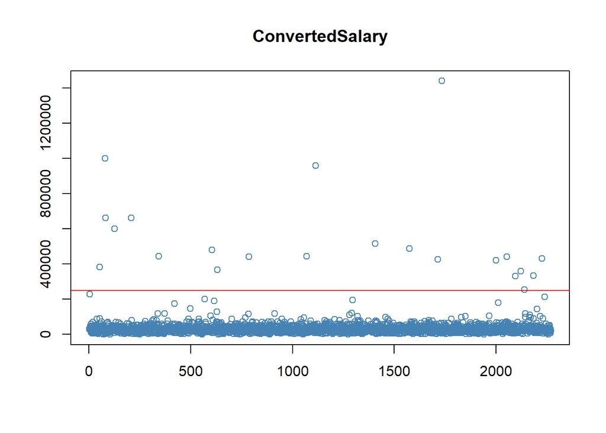

`Number of outliers`:

[1] 22

For **2019**:

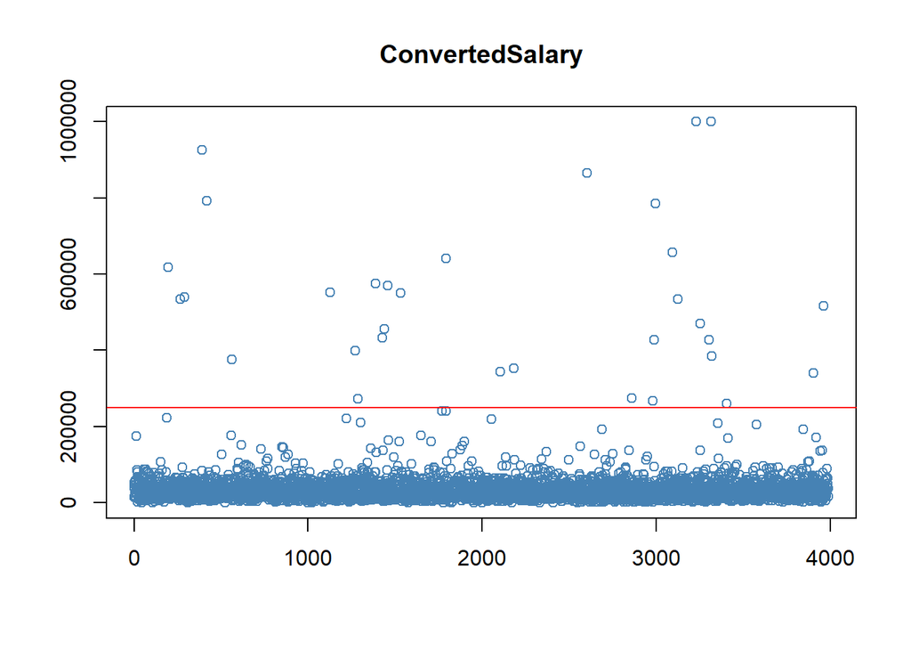

`Number of outliers:`

[1] 32

### 3.4.3) Data representation

After data cleaning

For **2018**:

Target variable:

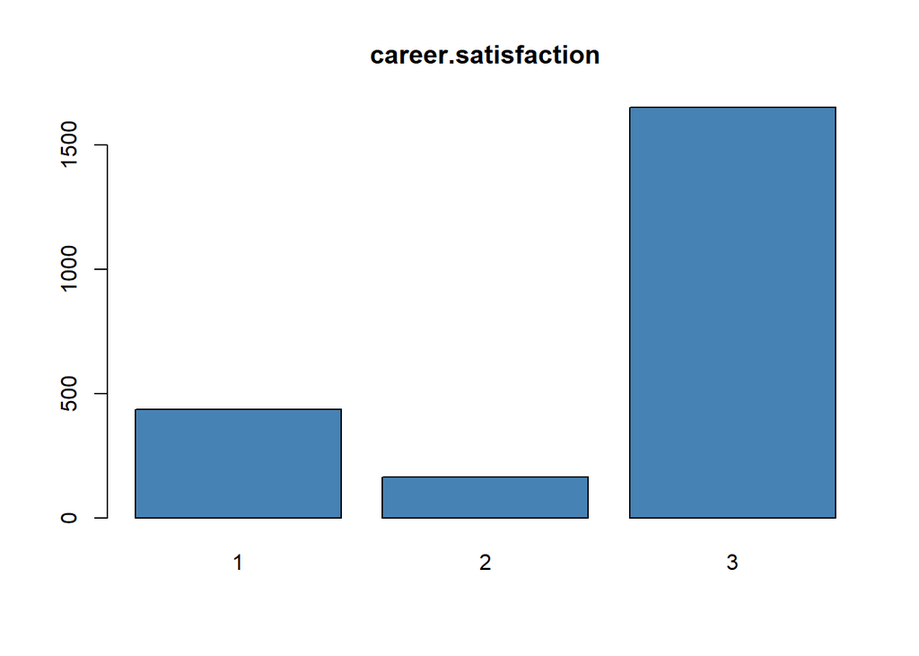

For **2019**:

Target variable:

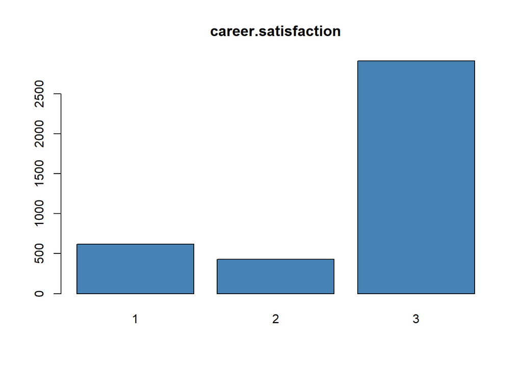

As per the plot it seems the data is **similarly distributed in both years**, it is still **imabalanced**, however, it is remarkable that the **second level (Neither satisfied nor dissatisfied) increased in 2019**. The reason behind could be due to the **number of available options**, which as mentioned above was **reduced from 7 to 5**.

For **2018**:

Covariates:

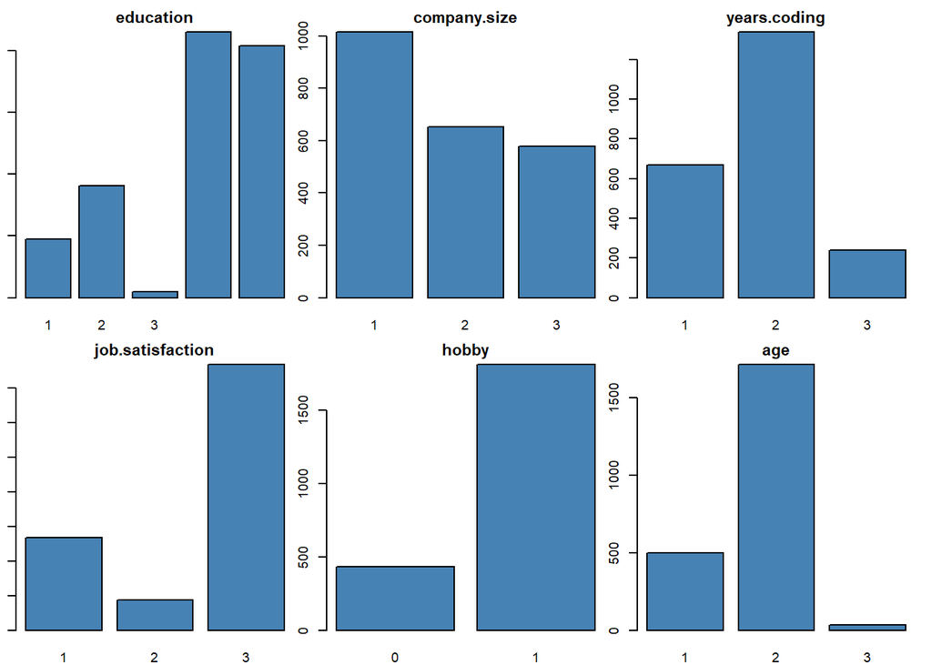

For **2019**:

Covariates:

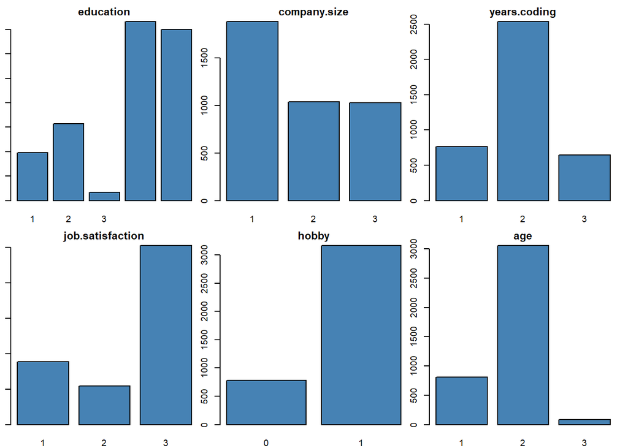

It seems the distribution of the **covariates is similar**, despite the increased number of participants in 2019 who have **more coding experience** (years.coding). On the other hand, similarly to the target variable, the variable **job.satisfaction** increased the second level, probably due to the same reasons as presented before.

### 3.4.4) Estimation

`Ordered choice logit model`

For **2018**:

|  | *Dependent variable:* |
| --- | --- |
| salary | 0.016*** |
|  | (0.003) |
| hobby1 | 0.357*** |
|  | (0.115) |
| years.coding2 | -0.093 |
|  | (0.114) |
| years.coding3 | -0.523*** |
|  | (0.183) |
| *Note:* | p<0.1; p<0.05; p<0.01 |

For **2019**:

|  | *Dependent variable:* |
| --- | --- |
| salary | 0.012*** |
|  | (0.002) |
| hobby1 | 0.378*** |
|  | (0.085) |
| years.coding2 | -0.085 |
|  | (0.094) |
| years.coding3 | -0.061 |
|  | (0.131) |
| *Note:* | p<0.1; p<0.05; p<0.01 |

`Best model of 2018 applied on 2019`

**Best model formula**: *`career.satisfaction ~ salary + hobby + job.neutral + job.satisfied`*

For **2018**:

|  | *Dependent variable:* |
| --- | --- |
| salary | 0.011*** |
|  | (0.003) |
| hobby1 | 0.427*** |
|  | (0.128) |
| job.neutral | 0.529*** |
|  | (0.164) |
| job.satisfied | 2.251*** |
|  | (0.114) |
| Threshold (1-> 2) | 0.520*** |
|  | (0.155) |
| Threshold (2-> 3) | 1.036*** |
|  | (0.156) |
| *Note:* | p<0.1; p<0.05; p<0.01 |

For **2019**:

|  | *Dependent variable:* |
| --- | --- |
| salary | 0.007*** |
|  | (0.002) |
| hobby1 | 0.392*** |
|  | (0.099) |
| job.neutral | 1.179*** |
|  | (0.105) |
| job.satisfied | 3.223*** |
|  | (0.100) |
| Threshold (1-> 2) | 0.433*** |
|  | (0.117) |
| Threshold (2-> 3) | 1.378*** |
|  | (0.120) |
| *Note:* | p<0.1; p<0.05; p<0.01 |

As seen above, the sign of the estimators is the same (even the values did not change a lot) and the significant level is the same in both years, hence, it can be seen that **the conclusions for 2018 can be applied also to 2019**:

When **salary** increases in 1K USD it affects, on average, positively on **career satisfaction**. People **who have coding as a hobby** are, on average, **more satisfied with their career** comparing with people who do not have coding as a hobby.

# 4) `Conclusions`

In both years the conclusions are the same, which is not a surprise- we are living in a material world, a capitalist world where money is [correlated with happiness](https://www.forbes.com/sites/alexledsom/2021/02/07/new-study-shows-that-more-money-buys-more-happiness/?sh=14f9199e70d5). The model output, higher salaries affect career satisfaction in a positive way, is inline with the western world conception. Having said that, another factor which positively affects your occupation happiness is your hobby. More precisely, a hobby which is the same as your job. The model shows that programmers who program as a hobby are incline to enjoy more in their job as programmers. Which, again, is not a surprise. As the saying goes “*Do what you love, and you’ll never work another day in your life.*”.  
The bottom line is: find a job you would enjoy doing even in your spare time. Just make sure it is a high pay job.

# 5) `Packages versions`

|  | x |
| --- | --- |
| stargazer | 5.2.2 |
| pscl | 1.5.5 |
| DescTools | 0.99.38 |
| brant | 0.3-0 |
| jtools | 2.1.3 |
| generalhoslem | 1.3.4 |
| reshape | 0.8.8 |
| oglmx | 3.0.0.0 |
| maxLik | 1.4-4 |
| miscTools | 0.6-26 |
| lmtest | 0.9-38 |
| zoo | 1.8-8 |
| MASS | 7.3-53 |
| psych | 2.0.9 |
| knitr | 1.30 |
| dplyr | 1.0.2 |